# Machine Learning Project

Claire Della Vedova

17 août, 2018

## 1. Background

Data used in this project come from accelerometers on the belt, forearm, arm, and dumbell.

Six participants were asked to perform barbell lifts correctly and incorrectly in 5 different ways :

- A - exactly according to the specification
- B - throwing the elbows to the front
- C - lifting the dumbbell only halfway
- D - lowering the dumbbell only halfway
- E - throwing the hips to the front

Using the data of these 6 participants **the aim of this Machine Learning project is to train a model to predict the manner in which 20 new participants did the exercise**.

[figure not shown]

*From : Velloso, Eduardo, et al. “Qualitative activity recognition of weight lifting exercises.” Proceedings of the 4th Augmented Human International Conference. ACM, 2013.*

*NB : More information is available from the website here: http://groupware.les.inf.puc-rio.br/har (see the section on the Weight Lifting Exercise Dataset).*

## 2. Data

The training data for this project are available here:

https://d396qusza40orc.cloudfront.net/predmachlearn/pml-training.csv

The test data are available here:

https://d396qusza40orc.cloudfront.net/predmachlearn/pml-testing.csv

The data for this project come from this source: http://groupware.les.inf.puc-rio.br/har.

```r
training <- read.csv("https://d396qusza40orc.cloudfront.net/predmachlearn/pml-training.csv")

testing <- read.csv("https://d396qusza40orc.cloudfront.net/predmachlearn/pml-testing.csv")
```

## 3. Packages needed

```r
library(tidyverse)
library(caret)
library(funModeling)
library(AppliedPredictiveModeling)
```

## 4. First look on data

### 4.1 Dimensions

```r
dim(training)
```

```
## [1] 19622   160
```

Training data contains 159 possible explanatory variables, and 19622 observations ! It will be impossible (beacause of time computation) to use all the available data to train the model.So latter in the project we’are going to use a little part of these data.

### 4.2 Structure

```r
str(training)
```

```
## 'data.frame':    19622 obs. of  160 variables:
##  $ X                       : int  1 2 3 4 5 6 7 8 9 10 ...
##  $ user_name               : Factor w/ 6 levels "adelmo","carlitos",..: 2 2 2 2 2 2 2 2 2 2 ...
##  $ raw_timestamp_part_1    : int  1323084231 1323084231 1323084231 1323084232 1323084232 1323084232 1323084232 1323084232 1323084232 1323084232 ...
##  $ raw_timestamp_part_2    : int  788290 808298 820366 120339 196328 304277 368296 440390 484323 484434 ...
##  $ cvtd_timestamp          : Factor w/ 20 levels "02/12/2011 13:32",..: 9 9 9 9 9 9 9 9 9 9 ...
##  $ new_window              : Factor w/ 2 levels "no","yes": 1 1 1 1 1 1 1 1 1 1 ...
##  $ num_window              : int  11 11 11 12 12 12 12 12 12 12 ...
##  $ roll_belt               : num  1.41 1.41 1.42 1.48 1.48 1.45 1.42 1.42 1.43 1.45 ...
##  $ pitch_belt              : num  8.07 8.07 8.07 8.05 8.07 8.06 8.09 8.13 8.16 8.17 ...
##  $ yaw_belt                : num  -94.4 -94.4 -94.4 -94.4 -94.4 -94.4 -94.4 -94.4 -94.4 -94.4 ...
##  $ total_accel_belt        : int  3 3 3 3 3 3 3 3 3 3 ...
##  $ kurtosis_roll_belt      : Factor w/ 397 levels "","-0.016850",..: 1 1 1 1 1 1 1 1 1 1 ...
##  $ kurtosis_picth_belt     : Factor w/ 317 levels "","-0.021887",..: 1 1 1 1 1 1 1 1 1 1 ...
##  $ kurtosis_yaw_belt       : Factor w/ 2 levels "","#DIV/0!": 1 1 1 1 1 1 1 1 1 1 ...
```

[output cut: 86 more lines]

Some variables seem to be factor by error and contains #DIV/0!“. I’m going to remove these factor variables.

### 4.3 Distribution of classe modalities

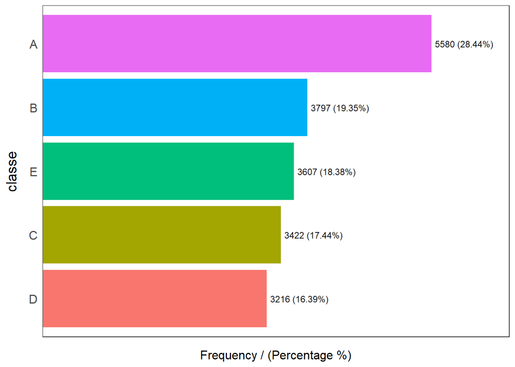

```
##   classe frequency percentage cumulative_perc
## 1      A      5580      28.44           28.44
## 2      B      3797      19.35           47.79
## 3      E      3607      18.38           66.17
## 4      C      3422      17.44           83.61
## 5      D      3216      16.39          100.00
```

```r
freq(data=training, input=c("classe"))
```

## 5. Explanatory variables selection

### 5.1 Remonving false factor variables

```r
# data set of exmplanatory variables (response variable is removed)
Descr_Var <-training %>%
    select(-classe)

# in this new data set, false factor variables are removed
Descr_Var2 <- Descr_Var %>%
    dplyr::select_if(~!is.factor(.x))
```

### 5.2 Removing variables with more than 10% of NA values

Using the df_status function of the funModeling package, we can see that some variables contain a high percentage of missing values. I’m going to remove all the explanatory variables having more than 10% of NA values using code available in *Casas, Pablo. Data Science Live Book: An intuitive and practical approach to data analysis, data preparation and machine learning, suitable for all ages! (p. 13). Édition du Kindle*.

```r
Descr_Var2_status <- df_status(Descr_Var2)
```

```
##                     variable q_zeros p_zeros  q_na  p_na q_inf p_inf
## 1                          X       0    0.00     0  0.00     0     0
## 2       raw_timestamp_part_1       0    0.00     0  0.00     0     0
## 3       raw_timestamp_part_2       0    0.00     0  0.00     0     0
## 4                 num_window       0    0.00     0  0.00     0     0
## 5                  roll_belt       5    0.03     0  0.00     0     0
## 6                 pitch_belt       1    0.01     0  0.00     0     0
## 7                   yaw_belt       3    0.02     0  0.00     0     0
## 8           total_accel_belt       3    0.02     0  0.00     0     0
## 9              max_roll_belt       0    0.00 19216 97.93     0     0
## 10            max_picth_belt       0    0.00 19216 97.93     0     0
## 11             min_roll_belt       0    0.00 19216 97.93     0     0
## 12            min_pitch_belt       2    0.01 19216 97.93     0     0
## 13       amplitude_roll_belt      12    0.06 19216 97.93     0     0
## 14      amplitude_pitch_belt      32    0.16 19216 97.93     0     0
```

[output cut: 233 more lines]

```r
# Removing variables with at least 10% of na values
vars_to_remove = filter( Descr_Var2_status, p_na >= 10) %>%
    .$ variable

vars_to_remove
```

```
##  [1] "max_roll_belt"            "max_picth_belt"
##  [3] "min_roll_belt"            "min_pitch_belt"
##  [5] "amplitude_roll_belt"      "amplitude_pitch_belt"
##  [7] "var_total_accel_belt"     "avg_roll_belt"
##  [9] "stddev_roll_belt"         "var_roll_belt"
## [11] "avg_pitch_belt"           "stddev_pitch_belt"
## [13] "var_pitch_belt"           "avg_yaw_belt"
## [15] "stddev_yaw_belt"          "var_yaw_belt"
## [17] "var_accel_arm"            "avg_roll_arm"
## [19] "stddev_roll_arm"          "var_roll_arm"
## [21] "avg_pitch_arm"            "stddev_pitch_arm"
## [23] "var_pitch_arm"            "avg_yaw_arm"
## [25] "stddev_yaw_arm"           "var_yaw_arm"
## [27] "max_roll_arm"             "max_picth_arm"
## [29] "max_yaw_arm"              "min_roll_arm"
```

[output cut: 19 more lines]

```r
# Keeping all columns except the ones present in 'vars_to_remove' vector
Descr_Var2 = select(Descr_Var2, -one_of( vars_to_remove))
```

### 5.3 Removing variables having Zero and near zero-variance Predictors:

To remove the explanatory variables having Zero or near zero-variance, I use the “nzv”" function of “caret” package

```r
nzv <- nearZeroVar(Descr_Var2, saveMetrics= TRUE)
nzv
```

```
##                      freqRatio percentUnique zeroVar   nzv
## X                     1.000000   100.0000000   FALSE FALSE
## raw_timestamp_part_1  1.000000     4.2656202   FALSE FALSE
## raw_timestamp_part_2  1.000000    85.5315462   FALSE FALSE
## num_window            1.000000     4.3726430   FALSE FALSE
## roll_belt             1.101904     6.7781062   FALSE FALSE
## pitch_belt            1.036082     9.3772296   FALSE FALSE
## yaw_belt              1.058480     9.9734991   FALSE FALSE
## total_accel_belt      1.063160     0.1477933   FALSE FALSE
## gyros_belt_x          1.058651     0.7134849   FALSE FALSE
## gyros_belt_y          1.144000     0.3516461   FALSE FALSE
## gyros_belt_z          1.066214     0.8612782   FALSE FALSE
## accel_belt_x          1.055412     0.8357966   FALSE FALSE
## accel_belt_y          1.113725     0.7287738   FALSE FALSE
## accel_belt_z          1.078767     1.5237998   FALSE FALSE
## magnet_belt_x         1.090141     1.6664968   FALSE FALSE
## magnet_belt_y         1.099688     1.5187035   FALSE FALSE
## magnet_belt_z         1.006369     2.3290184   FALSE FALSE
## roll_arm             52.338462    13.5256345   FALSE FALSE
## pitch_arm            87.256410    15.7323412   FALSE FALSE
## yaw_arm              33.029126    14.6570176   FALSE FALSE
## total_accel_arm       1.024526     0.3363572   FALSE FALSE
## gyros_arm_x           1.015504     3.2769341   FALSE FALSE
## gyros_arm_y           1.454369     1.9162165   FALSE FALSE
## gyros_arm_z           1.110687     1.2638875   FALSE FALSE
## accel_arm_x           1.017341     3.9598410   FALSE FALSE
## accel_arm_y           1.140187     2.7367241   FALSE FALSE
## accel_arm_z           1.128000     4.0362858   FALSE FALSE
## magnet_arm_x          1.000000     6.8239731   FALSE FALSE
## magnet_arm_y          1.056818     4.4439914   FALSE FALSE
## magnet_arm_z          1.036364     6.4468454   FALSE FALSE
## roll_dumbbell         1.022388    84.2065029   FALSE FALSE
## pitch_dumbbell        2.277372    81.7449801   FALSE FALSE
## yaw_dumbbell          1.132231    83.4828254   FALSE FALSE
## total_accel_dumbbell  1.072634     0.2191418   FALSE FALSE
## gyros_dumbbell_x      1.003268     1.2282132   FALSE FALSE
## gyros_dumbbell_y      1.264957     1.4167771   FALSE FALSE
## gyros_dumbbell_z      1.060100     1.0498420   FALSE FALSE
## accel_dumbbell_x      1.018018     2.1659362   FALSE FALSE
## accel_dumbbell_y      1.053061     2.3748853   FALSE FALSE
## accel_dumbbell_z      1.133333     2.0894914   FALSE FALSE
## magnet_dumbbell_x     1.098266     5.7486495   FALSE FALSE
## magnet_dumbbell_y     1.197740     4.3012945   FALSE FALSE
## magnet_dumbbell_z     1.020833     3.4451126   FALSE FALSE
## roll_forearm         11.589286    11.0895933   FALSE FALSE
## pitch_forearm        65.983051    14.8557741   FALSE FALSE
## yaw_forearm          15.322835    10.1467740   FALSE FALSE
## total_accel_forearm   1.128928     0.3567424   FALSE FALSE
## gyros_forearm_x       1.059273     1.5187035   FALSE FALSE
## gyros_forearm_y       1.036554     3.7763735   FALSE FALSE
## gyros_forearm_z       1.122917     1.5645704   FALSE FALSE
## accel_forearm_x       1.126437     4.0464784   FALSE FALSE
## accel_forearm_y       1.059406     5.1116094   FALSE FALSE
## accel_forearm_z       1.006250     2.9558659   FALSE FALSE
## magnet_forearm_x      1.012346     7.7667924   FALSE FALSE
## magnet_forearm_y      1.246914     9.5403119   FALSE FALSE
## magnet_forearm_z      1.000000     8.5771073   FALSE FALSE
```

There are no explanatory variables having Zero or near zero-variance

```r
dim(Descr_Var2)
```

```
## [1] 19622    56
```

Now there are 56 possible predictors variables.

### 5.4 Removing other variables

#### 5.4.1 X variable

X variable has no information, is row index, so I’m going to remove it.

```r
Descr_Var2 <- Descr_Var2 %>%
    select(-"X")
```

#### 5.4.2 Date and Time variables

Date and Time variables have no usable informations.So, I’m going to remove theù too.

```r
Descr_Var2 <- Descr_Var2 %>%
    select(-matches("times"))
```

#### 5.4.3 num_window variable

As the same for the “num_window” variable.

```r
Descr_Var2 <- Descr_Var2 %>%
    select(-"num_window")
```

### 5.5 Removing high correlated predictors (cutoff used= 0.75)

```r
Descr_Var2_Cor <-  cor(Descr_Var2)
highlyCorDescr <- findCorrelation(Descr_Var2_Cor, cutoff = .75)

Descr_Var3 <- Descr_Var2[,-highlyCorDescr]
```

### 5.6 Removing Linear combination

```r
comboInfo <- findLinearCombos(Descr_Var3)
comboInfo
```

```
## $linearCombos
## list()
##
## $remove
## NULL
```

No linear combination, so no variable to remove

```r
ncol(Descr_Var3)
```

```
## [1] 31
```

## 6. Split training into training and valid sets

### 6.1 Applying variable selection on training

```r
selected_variables <- names(Descr_Var3)

# adding classe Variable
selected_variables <- c( selected_variables, names(training)[ncol(training)])
```

```r
training2 <- training %>%
    select(one_of(selected_variables))
```

### 6.2 Split training into train_dat and valid_data sets

Since the training data set contains too much lines to train the model (because of calculus time), we need to select a little part of them. I choose to use 25% of the 19622 observations, i.e 4907 observations. And, also I limit the explanatory variable to those previously selected.

```r
p_init <- 0.25

set.seed(1234)
indTmp <- createDataPartition(y=training2$classe, p=p_init, list=FALSE)
tmp_data <- training2[indTmp,]
```

```r
dim(tmp_data)
```

```
## [1] 4907   32
```

Then, I split this part of training data into train and valid datasets. The train part will be used to train machine learning models, and the valid dataset will be used to assess their performance.

```r
set.seed(1234)
indTrain <- createDataPartition(y=tmp_data$classe, p=0.75, list=FALSE)
train_data <- tmp_data[indTrain,]
valid_data <- tmp_data[-indTrain,]
```

The train data contains 75% of the kept rows, i.e 3682 rows. The valid dataset contains 1225 rows.

```r
dim(train_data)
```

```
## [1] 3682   32
```

```r
dim(valid_data)
```

```
## [1] 1225   32
```

## 7. Train Models

Since random forests are known to have good performance in classification machine learning problems, I chose to use this kind of model.

### 7.1 Random Forest

```r
mod_rf <- train(classe~., data=train_data, method="rf", prox=TRUE)
pred_rf <- predict(mod_rf, valid_data)
CM_rf <- confusionMatrix(valid_data$classe, pred_rf)
CM_rf
```

```
## Confusion Matrix and Statistics
##
##           Reference
## Prediction   A   B   C   D   E
##          A 346   2   0   0   0
##          B  15 213   7   1   1
##          C   2  11 197   4   0
##          D   1   1   8 188   3
##          E   0   0   2   2 221
##
## Overall Statistics
##
##                Accuracy : 0.951
##                  95% CI : (0.9374, 0.9624)
##     No Information Rate : 0.2971
##     P-Value [Acc > NIR] : < 2.2e-16
##
##                   Kappa : 0.938
##  Mcnemar's Test P-Value : NA
##
## Statistics by Class:
##
##                      Class: A Class: B Class: C Class: D Class: E
## Sensitivity            0.9505   0.9383   0.9206   0.9641   0.9822
## Specificity            0.9977   0.9760   0.9832   0.9874   0.9960
## Pos Pred Value         0.9943   0.8987   0.9206   0.9353   0.9822
## Neg Pred Value         0.9795   0.9858   0.9832   0.9932   0.9960
## Prevalence             0.2971   0.1853   0.1747   0.1592   0.1837
## Detection Rate         0.2824   0.1739   0.1608   0.1535   0.1804
## Detection Prevalence   0.2841   0.1935   0.1747   0.1641   0.1837
## Balanced Accuracy      0.9741   0.9571   0.9519   0.9757   0.9891
```

```r
eose_rf <- round(CM_rf$overall[1],3)
```

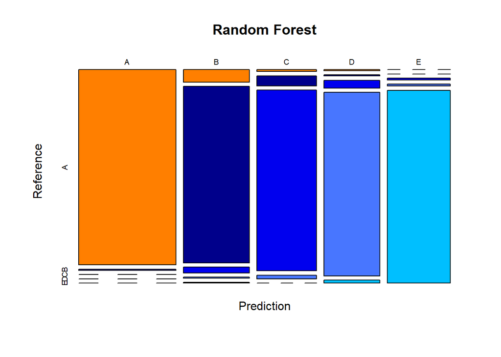

```r
plot(CM_rf$table, color=c("#FF7F00", "#00008B", "#0000EE", "#4876FF", "#00BFFF"), main="Random Forest")
```

### 7.2 Boosting with tree

As a second kind a model, I chose to use a Generalized Boosted Model because it’s also known as having good performance in classification.

```r
mod_gbm <- train(classe~., data=train_data, method="gbm", verbose = FALSE)
pred_gbm <- predict(mod_gbm, valid_data)
CM_gbm <- confusionMatrix(valid_data$classe, pred_gbm)
CM_gbm
```

```
## Confusion Matrix and Statistics
##
##           Reference
## Prediction   A   B   C   D   E
##          A 332   8   3   5   0
##          B  18 204  13   0   2
##          C   0  15 191   8   0
##          D   1   4   9 185   2
##          E   2   6   8   7 202
##
## Overall Statistics
##
##                Accuracy : 0.9094
##                  95% CI : (0.8919, 0.9249)
##     No Information Rate : 0.2882
##     P-Value [Acc > NIR] : < 2.2e-16
##
##                   Kappa : 0.8854
##  Mcnemar's Test P-Value : 0.001505
##
## Statistics by Class:
##
##                      Class: A Class: B Class: C Class: D Class: E
## Sensitivity            0.9405   0.8608   0.8527   0.9024   0.9806
## Specificity            0.9817   0.9666   0.9770   0.9843   0.9774
## Pos Pred Value         0.9540   0.8608   0.8925   0.9204   0.8978
## Neg Pred Value         0.9761   0.9666   0.9674   0.9805   0.9960
## Prevalence             0.2882   0.1935   0.1829   0.1673   0.1682
## Detection Rate         0.2710   0.1665   0.1559   0.1510   0.1649
## Detection Prevalence   0.2841   0.1935   0.1747   0.1641   0.1837
## Balanced Accuracy      0.9611   0.9137   0.9149   0.9434   0.9790
```

```r
eose_gbm <- round(CM_gbm$overall[1],3)
```

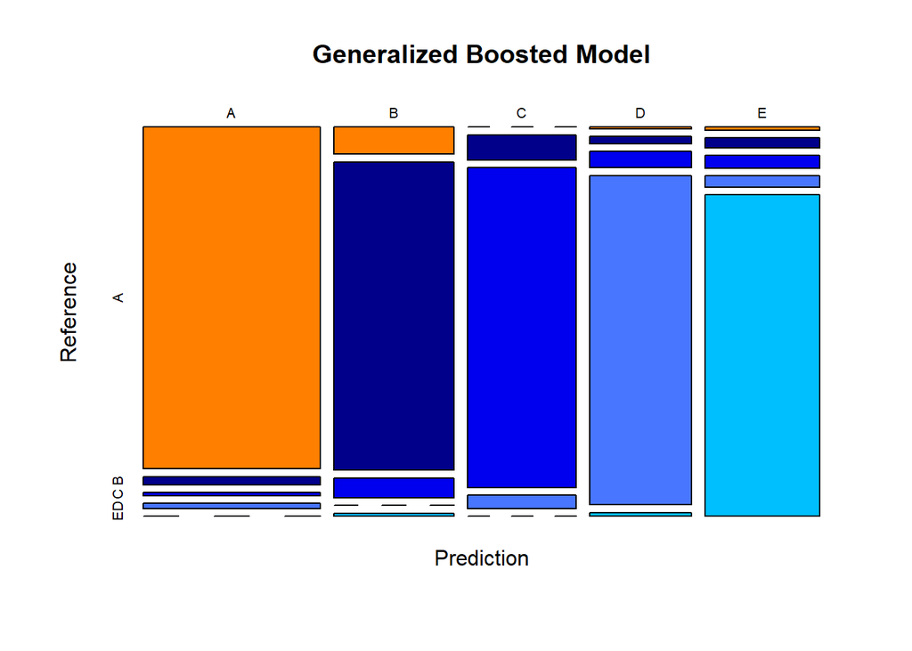

```r
plot(CM_gbm$table, color=c("#FF7F00", "#00008B", "#0000EE", "#4876FF", "#00BFFF"), main="Generalized Boosted Model")
```

We can see tah erros of prediction are not the same of the random forets model.